# The ChatGPT Shock and Public Information about AI and Work

# 5 Results

## 5.1 Volume Shock

We begin with the most basic question: did media attention to AI and labour change discontinuously at the ChatGPT launch? Figure @ref(fig-volume-shock) plots the monthly count of articles in the corpus, with the fitted values from an interrupted-time-series (ITS) regression overlaid. Three reference dates are marked: the ChatGPT launch in December 2022, the GPT-4 release in March 2023, and the adoption of the EU AI Act in March 2024.

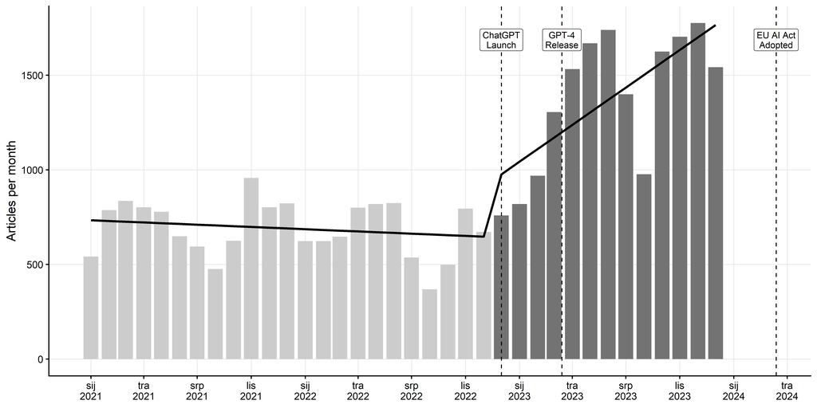

Figure 1: Monthly article volume in the AI–labour corpus, with fitted interrupted-time-series trend. Reference lines mark the ChatGPT launch (December 2022), the GPT-4 release (March 2023), and the EU AI Act adoption (March 2024).

Table 2: Interrupted-time-series estimates for monthly article volume. Standard errors are HAC-robust.

| Term | Estimate | SE | t_value | p_value |
| --- | --- | --- | --- | --- |
| Intercept (baseline level) | 733.77 | 55.09 | 13.32 | 0.0000000000000134 |
| Pre-trend (per month) | -3.90 | 4.30 | -0.91 | 0.371083 |
| Level shift (ChatGPT) | -1268.76 | 568.40 | -2.23 | 0.032731 |
| Slope change (post-trend) | 68.76 | 17.11 | 4.02 | 0.000332 |